# Practice 4 HW

2025-03-24

```r
library(tidyverse)
library(rstatix)
library(effsize)
library(psych)
library(car)
library(DescTools)
library(sjstats)
data <- read.csv('Medinfo.csv', sep=";")
```

Do people from different regions have different levels of health anxiety?

Now let’s filter the data so it is easier to analyze. We will create a subset

```r
subset <- data %>%
  select(OUTPUT.reg, total_hecons)
```

```r
str(subset)
```

```
## 'data.frame':    1353 obs. of  2 variables:
##  $ OUTPUT.reg  : chr  "Moscow" "Moscow" "Moscow" "Siberian Federal District" ...
##  $ total_hecons: int  17 29 24 25 24 18 20 21 16 22 ...
```

We need to change the region variable into the factor so it can be analyzed.

```r
subset <- rename(subset, "region" = "OUTPUT.reg")
```

```r
subset$region <- as.factor(subset$region)
```

```r
levels(subset$region)
```

```
##  [1] "Central Federal District"        "Far Eastern Federal District"
##  [3] "Moscow"                          "North Caucasus Federal District"
##  [5] "Northwestern Federal District"   "Saint-Petersburg"
##  [7] "Siberian Federal District"       "Southern Federal District"
##  [9] "Ural federal district"           "Volga Federal District"
```

Returning to the question, it can be seen that we need to see the differences between the 10 groups. For this ANOVA test or its non-parametric alternative can be used.

Do people from different regions have different levels of health anxiety?

H1: There is a difference in levels of healthy anxiety between the people from different regions H0: There is no difference in levels of healthy anxiety between the people from different regions

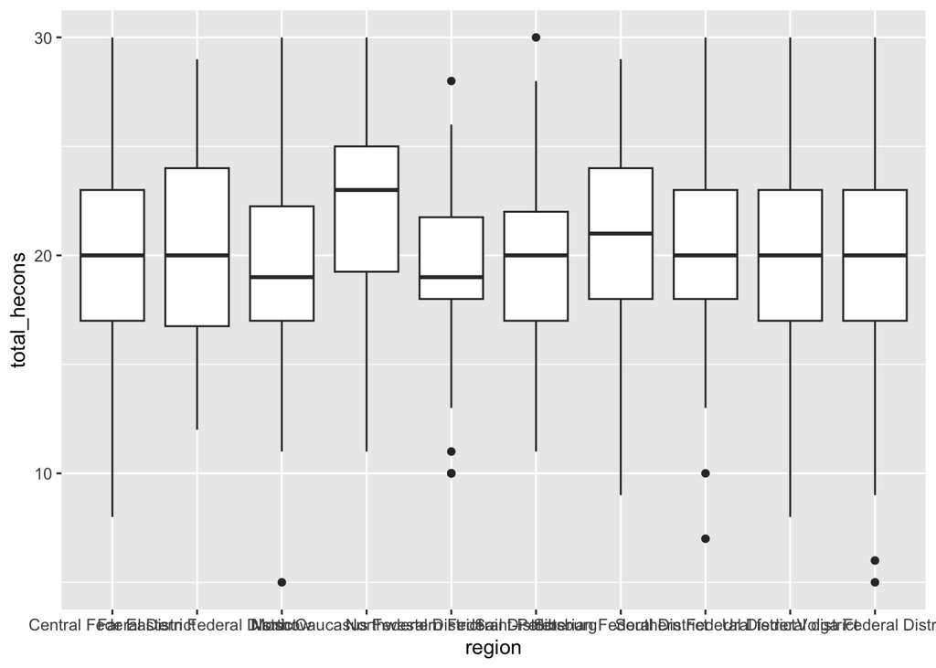

```r
ggplot(data = subset, aes(x = region, y = total_hecons))+
  geom_boxplot()
```

It can be seen from the boxplots that there seems to be the difference of total_hecons between the groups of regions.

It can be seen from the boxplot that there are some outliers that needs to be removed

Let’s look at the histogram

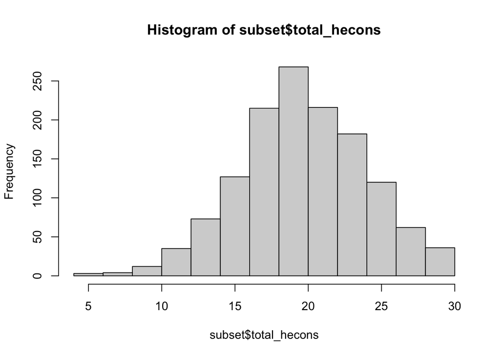

```r
hist(subset$total_hecons)
```

The distribution seems to be normal6 though there are some outliers in the left tail.

We will delete the outliers, using the Z-score. We will remove the data that exceeds 3 std.

```r
z_score = scale(subset$total_hecons)
```

```r
describe(z_score)
```

```
##    vars    n mean sd median trimmed  mad   min  max range skew kurtosis   se
## X1    1 1353    0  1  -0.03    0.01 1.03 -3.51 2.28  5.79 -0.1    -0.06 0.03
```

```r
drop_outliers <- subset$total_hecons[which(z_score < -3)]
subset_clean <- subset[!(subset$total_hecons %in% drop_outliers), ]
```

Now let’s look at the boxplot of clean data

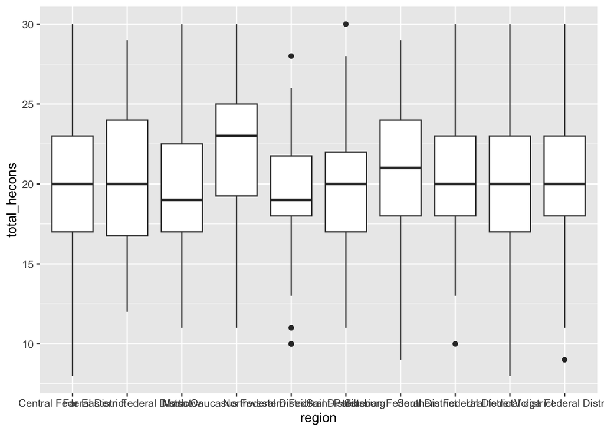

```r
ggplot(data = subset_clean, aes(x = region, y = total_hecons))+
  geom_boxplot()
```

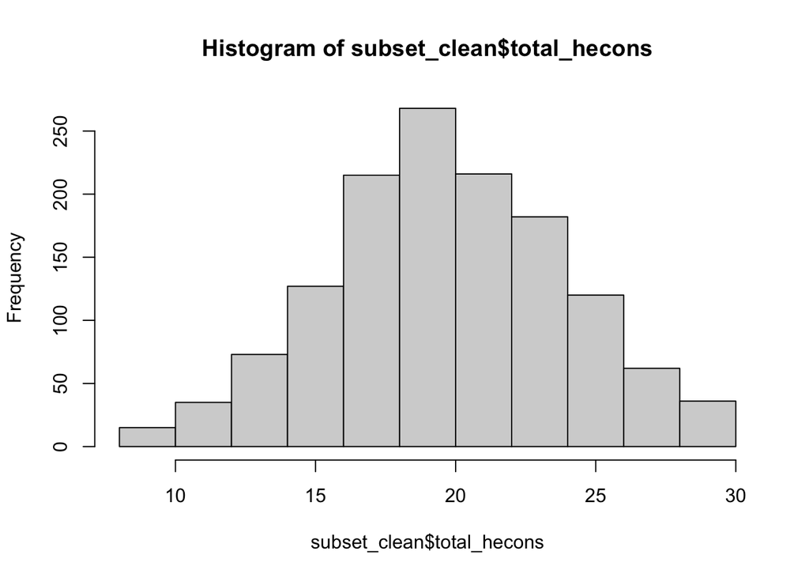

```r
hist(subset_clean$total_hecons)
```

Now the distribution looks much better^ so now we are ready to check the assumptions

Now let’s check the assumptions Assumption 1. Independence: Observations should be independent of each other. The data is independent as each observation is a unique person (Assumption 1 is met)

Assumption 2. Homogeneity of variances. Let’s check this assumption. For this we are going to run a Levene’s test.

```r
leveneTest(subset_clean$total_hecons ~ subset_clean$region)
```

```
## Levene's Test for Homogeneity of Variance (center = median)
##         Df F value Pr(>F)
## group    9  1.1253 0.3412
##       1339
```

The variances are equal as the p-value is greater than .05 meaning that the assumption is met for the test.

Assumption 3. Normality of the residuals Let’s check it by running an ANOVA test and then checking the residuals

```r
aov.put <- aov(subset_clean$total_hecons ~ subset_clean$region)
```

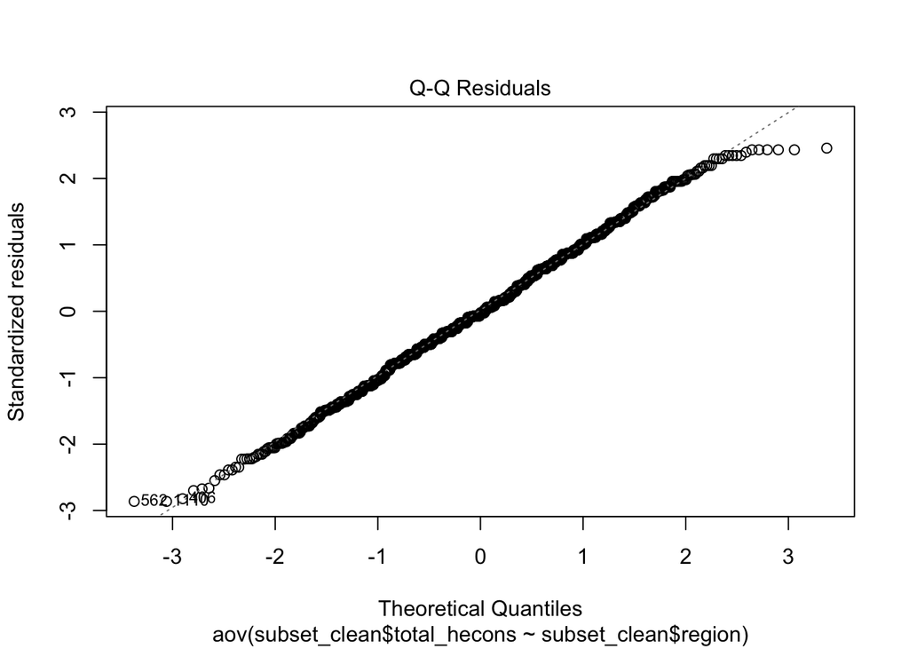

```r
plot(aov.put, 2)
```

The distribution seems practically normal6 there are practically no outliers there

Let’s run the shapiro test for normality

```r
shapiro.test(aov.put$residuals)
```

```
##
##  Shapiro-Wilk normality test
##
## data:  aov.put$residuals
## W = 0.99709, p-value = 0.01368
```

It can be seen that the p-value is less than 0.05, though it is quite close to it, so we will run both tests parametric and non-parametric test

```r
oneway.test(subset_clean$total_hecons ~ subset_clean$region, var.equal = T)
```

```
##
##  One-way analysis of means
##
## data:  subset_clean$total_hecons and subset_clean$region
## F = 2.2994, num df = 9, denom df = 1339, p-value = 0.0146
```

As it can be seen the result shows that the p-value is less that 0.05, meaning that there is the difference in means of total_hecons between the groups.

Meaning that the null hypothesis is rejected.

```r
TukeyHSD(aov.put)
```

```
##   Tukey multiple comparisons of means
##     95% family-wise confidence level
##
## Fit: aov(formula = subset_clean$total_hecons ~ subset_clean$region)
##
## $`subset_clean$region`
##                                                                       diff
## Far Eastern Federal District-Central Federal District          0.290215924
## Moscow-Central Federal District                               -0.356275304
## North Caucasus Federal District-Central Federal District       2.066882591
## Northwestern Federal District-Central Federal District        -0.759784076
## Saint-Petersburg-Central Federal District                     -0.440056184
## Siberian Federal District-Central Federal District             0.294637693
## Southern Federal District-Central Federal District             0.654974194
## Ural federal district-Central Federal District                -0.193117409
## Volga Federal District-Central Federal District                0.204071346
## Moscow-Far Eastern Federal District                           -0.646491228
## North Caucasus Federal District-Far Eastern Federal District   1.776666667
## Northwestern Federal District-Far Eastern Federal District    -1.050000000
## Saint-Petersburg-Far Eastern Federal District                 -0.730272109
## Siberian Federal District-Far Eastern Federal District         0.004421769
## Southern Federal District-Far Eastern Federal District         0.364758270
## Ural federal district-Far Eastern Federal District            -0.483333333
## Volga Federal District-Far Eastern Federal District           -0.086144578
## North Caucasus Federal District-Moscow                         2.423157895
## Northwestern Federal District-Moscow                          -0.403508772
## Saint-Petersburg-Moscow                                       -0.083780881
## Siberian Federal District-Moscow                               0.650912997
## Southern Federal District-Moscow                               1.011249498
## Ural federal district-Moscow                                   0.163157895
## Volga Federal District-Moscow                                  0.560346650
## Northwestern Federal District-North Caucasus Federal District -2.826666667
## Saint-Petersburg-North Caucasus Federal District              -2.506938776
## Siberian Federal District-North Caucasus Federal District     -1.772244898
## Southern Federal District-North Caucasus Federal District     -1.411908397
## Ural federal district-North Caucasus Federal District         -2.260000000
## Volga Federal District-North Caucasus Federal District        -1.862811245
## Saint-Petersburg-Northwestern Federal District                 0.319727891
## Siberian Federal District-Northwestern Federal District        1.054421769
## Southern Federal District-Northwestern Federal District        1.414758270
```

[output cut: 135 more lines]

```
## Saint-Petersburg-Northwestern Federal District                0.9999816
## Siberian Federal District-Northwestern Federal District       0.8060533
## Southern Federal District-Northwestern Federal District       0.4471678
## Ural federal district-Northwestern Federal District           0.9968856
## Volga Federal District-Northwestern Federal District          0.8256899
## Siberian Federal District-Saint-Petersburg                    0.9464397
## Southern Federal District-Saint-Petersburg                    0.6434318
## Ural federal district-Saint-Petersburg                        0.9999911
## Volga Federal District-Saint-Petersburg                       0.9588407
## Southern Federal District-Siberian Federal District           0.9994664
## Ural federal district-Siberian Federal District               0.9944110
## Volga Federal District-Siberian Federal District              1.0000000
## Ural federal district-Southern Federal District               0.8391590
## Volga Federal District-Southern Federal District              0.9929867
## Volga Federal District-Ural federal district                  0.9973529
```

Statistically Significant Comparisons (p < 0.05)

North Caucasus Federal District vs. Moscow diff = 2.423, p = 0.01397 Interpretation: People from the North Caucasus Federal District have significantly higher health anxiety than those from Moscow.

Northwestern Federal District vs. North Caucasus Federal District diff = -2.827, p = 0.01392 Interpretation: People from the Northwestern Federal District have significantly lower health anxiety than those from the North Caucasus Federal District.

Saint-Petersburg vs. North Caucasus Federal District diff = -2.507, p = 0.02352 Interpretation: People from Saint-Petersburg have significantly lower health anxiety than those from the North Caucasus Federal District.

Ural Federal District vs. North Caucasus Federal District diff = -2.260, p = 0.04434 Interpretation: People from the Ural Federal District have significantly lower health anxiety than those from the North Caucasus Federal District.

Let’s check the effect size

```r
anova_stats(aov.put)
```

```
## etasq | partial.etasq | omegasq | partial.omegasq | epsilonsq | cohens.f
## ------------------------------------------------------------------------
## 0.015 |         0.015 |   0.009 |           0.009 |     0.009 |    0.124
##       |               |         |                 |           |
##
## etasq |                term |     sumsq |   df | meansq | statistic | p.value | power
## -------------------------------------------------------------------------------------
## 0.015 | subset_clean$region |   370.691 |    9 | 41.188 |     2.299 |   0.015 | 0.915
##       |           Residuals | 23985.083 | 1339 | 17.913 |           |         |
```

The effect is rather small maening that actually the region does not play a crucial role in the level of health anxiety.

Now, let’s run a non-parametric test

```r
kruskal.test(subset_clean$total_hecons, subset_clean$region)
```

```
##
##  Kruskal-Wallis rank sum test
##
## data:  subset_clean$total_hecons and subset_clean$region
## Kruskal-Wallis chi-squared = 22.054, df = 9, p-value = 0.00871
```

Kruskal test shows that there is a statistically significant difference between the groups, meaning that we reject the null hypothesis.

Now let’s run a post hoc test

```r
dunn_test(subset_clean, total_hecons ~ region)
```

```
## # A tibble: 45 × 9
##    .y.          group1  group2    n1    n2 statistic       p  p.adj p.adj.signif
##  * <chr>        <chr>   <chr>  <int> <int>     <dbl>   <dbl>  <dbl> <chr>
##  1 total_hecons Centra… Far E…   247    60    0.380  7.04e-1 1      ns
##  2 total_hecons Centra… Moscow   247   171   -1.23   2.18e-1 1      ns
##  3 total_hecons Centra… North…   247    50    3.34   8.41e-4 0.0353 *
##  4 total_hecons Centra… North…   247    66   -0.987  3.23e-1 1      ns
##  5 total_hecons Centra… Saint…   247    98   -0.712  4.76e-1 1      ns
##  6 total_hecons Centra… Siber…   247   147    1.03   3.04e-1 1      ns
##  7 total_hecons Centra… South…   247   131    1.29   1.98e-1 1      ns
##  8 total_hecons Centra… Ural …   247   130   -0.0838 9.33e-1 1      ns
##  9 total_hecons Centra… Volga…   247   249    0.616  5.38e-1 1      ns
## 10 total_hecons Far Ea… Moscow    60   171   -1.18   2.38e-1 1      ns
## # ℹ 35 more rows
```

Significant Differences (p < 0.05, assuming):

Now let’s calculate the effect size

```r
kruskal_effsize(subset_clean, total_hecons ~ region)
```

```
## # A tibble: 1 × 5
##   .y.              n effsize method  magnitude
## * <chr>        <int>   <dbl> <chr>   <ord>
## 1 total_hecons  1349 0.00975 eta2[H] small
```

The effect size is again small, meaning that though there is a difference between the groups, it can be stated that the region does not play the key role in the levels of health anxiety as the effect size is small

The conclusion In summary, we accept H₁ and conclude that health anxiety levels vary across Russian regions, with the North Caucasus Federal District reporting the highest levels. However, since the effect size is small, these differences, while statistically detectable, may not be large enough to be sociologically impactful without further contextual analysis.